# Comparing Values Across the Pacific Ocean

Ayush Lahiri, Jianing Gong, Madhvi Malhotra, Minh Quach, Sean Hambali

06 December 2022

## Background

**Context**

- As of 2019, there were 14.1 million immigrants from Asia residing in the United States
- In the 2020/21 academic year a combined total of 645,622 students from across East Asia, South and Central Asia, and Southeast Asia studied in the United States
- Asian countries shared different ideological, religious and cultural origins as the US

  |  | Asian Countries | US |
  | --- | --- | --- |
  | Ideology | Socialist/Authoritarian/Democratic | Democratic |
  | Main Religion | Islam/Buddhism/Hinduism and many more | 64% Christian and 30% None |
  | Development | Upper middle income - Indonesia, China Lower middle Income - Vietnam | High income |

## Research Framework

- Targeted countries: United States, China, Indonesia, Vietnam
- Analysis Dimensions: Social, Economic, Religious, Political
- Data Resources: World Values Survey, World Values Association, Wave 7 (2017-2022)

**Our Research Question**

How do Vietnamese, Chinese and Indonesian values differ from that of the US across economic, social, political and religious domains?

**Examples of constituent variables in each dimension**:

- **Social Dimension:** Importance of family and friends, Espousing intolerance towards marginalized groups and so on
- **Economic Dimension:**Private ownership of business, Should incomes be equal
- **Religious Dimension:** Is god important in my life, In science v/s religions, religion is always right
- **Political Dimension:** Political matter, Fight for views

## Theory

**Why Indonesia, Vietnam, and China? It’s more than just personal.**

- Wide diversity in terms of religion, politics, climate, and economic structure
- Referencing the Inglehart-Welzel cultural maps over the years

**Many influences, many controls**

- Sex (Kitano et al., 1998) - Immigration - Education level (Welzel, 2011)
- Age (Hsin and Xie, 2014) - Marital status (Kitano et al., 1998) - Income

**Choices of topic and question**

We look at the supposed cornerstones of the ‘Asian values’: *familialism, communalism, authority orientations, and work ethic* (Kim, 2010) in conjunction with the main focuses of the Public Religion Research Institute’s American Values Survey on the *social, economic, religious, and political* dimensions of America (PRRI, 2022).

## Theory

**Based on the reviewed literature, we expect two main themes:**

- There would be *some* significant differences between our sampled countries and the US, as well as significant differences among the sampled countries themselves.
- Due to the growing popularity of progressive ideals and viewpoints oriented towards ‘emancipative values’ in recent decades, our sampled countries might be closer to the US, on certain issues of the social, economic, and political dimensions, than previously perceived.

# Methods

## How are we doing it?

- Using the World Values Survey (WVS) Wave 7 data
- Estimating the following logit model:

## Analysis Steps

First, we define some recoding functions for the cleaning process:

```r
# first, we define some cleaning functions for recoding columns that
# will be used throughout the cleaning process.

# 1. recoding 2 options - 1 = Y, 2 = N
binary_recode_2opt <- function(x) {
  x[x==2] <- 0
  x
}

# 2. RECODING 3 options (with neutral choice as 3rd opt)
binary_recode_3opt <- function(x) {
  x[x >= 2] <- 0
  x
}
```

## Analysis Steps

- We recode the columns into binary variable
- Clean the demographics and survey-related columns
- Keep only the newly generated binary, demographics and survey-related columns

```r
wvs7_working <- wvs7 %>%
 mutate(survey_year = A_YEAR,
        survey_type = "WVS",
        survey_wave = A_WAVE,
        ...
        ) %>%
 mutate(
   important_fam = binary_recode_4opt(Q1),
   important_fr = binary_recode_4opt(Q2),
   ...
 ) %>%
 mutate(eql_inc = binary_recode_10opt(Q106),
        ...
        ) %>%
 mutate(
   sex = factor(Q260, levels = c(1,2),
                labels = c("Male", "Female")),
   ...
 )
```

## Analysis Steps

For the regressions, we define several functions that:

```r
# defining the regression function
reg_func <- function(yvar) {

  # defining the regression function
  result <- glm(eval(parse(text = yvar)) ~
                  relevel(factor(country_iso), ref = "United States") +
                  sex + age + immigrant + marital +
                  educ_group + work + income_3,
                data = wvs7_working)

  # outputting the result
  result
}

# defining the function to get tidy model and obtain the odds-ratio SE
tidy_model <- function(model) {

  # following the steps outlined in andrew heiss's blog:
  tidy <- broom::tidy(model) %>%
    mutate(or = exp(estimate),
           var_diag = diag(vcov(model)),
           or_se = sqrt(or^2 * var_diag),
           or_ll = or - (1.96*or_se),
           or_ul = or + (1.96*or_se))

  # returning the result
  tidy
}
```

## Analysis Steps

We then apply these functions to create a tidy data frame containing the model results:

```r
# storing dep vars of interest in a vector
dep_vars <- c("important_fam", "important_fr",
              "neighbor_diffrace", "neighbor_gay", "neighbor_imm",
              "gender_jobs",
              "happy", "health",
              "trust", "trust_fam", "trust_first")

# applying the reg function to all dep_vars
model_results <- map(dep_vars, reg_func)
names(model_results) <- dep_vars    # assigning the dep_Var names as element name

# creating a tidy data out of the model results
model_results_df <-  model_results %>%
  map(tidy_model)

# binding the rows together, creating a single df
model_results_df <- bind_rows(model_results_df, .id = "dep_var") %>%
  mutate(

    # description for the dep. vars
    var_desc = case_when(
      dep_var == "important_fam" ~ "Family",
      dep_var == "important_fr" ~ "Friends",
      dep_var == "neighbor_diffrace" ~ "Different race",
      dep_var == "neighbor_gay" ~ "Homosexuals",
      dep_var == "neighbor_imm" ~ "Immigrants",
      dep_var == "gender_jobs" ~ "Males have more \nright to jobs",
      dep_var == "happy" ~ "Happy",
      dep_var == "health" ~ "Health",
      dep_var == "trust" ~ "Most people",
      dep_var == "trust_fam" ~ "Family",
      dep_var == "trust_first" ~ "First-timers"
    )
  )
```

## Sample Distribution

Most of our observations in the WVS Wave-7 came from **Canada**, **Indonesia**, **China**, **United States** and **Turkey**.

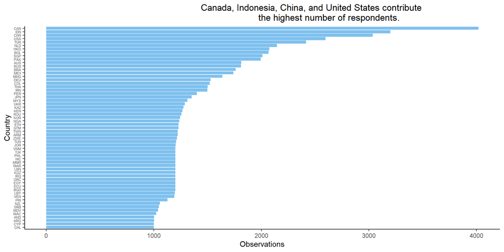

Canada, Indonesia, China, and United States contribute the highest number of respondents.

## Sample Distribution

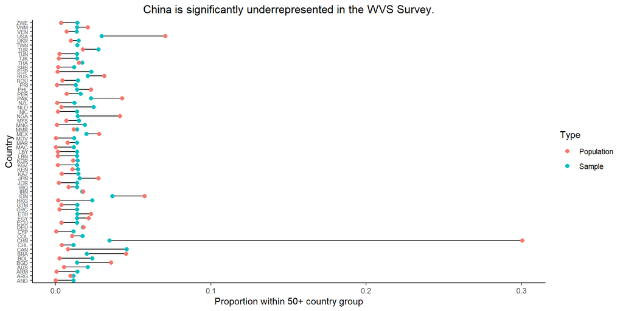

# Results

## Social Dimension

The World Values Survey data suggests significant societal differences even within Asian countries.

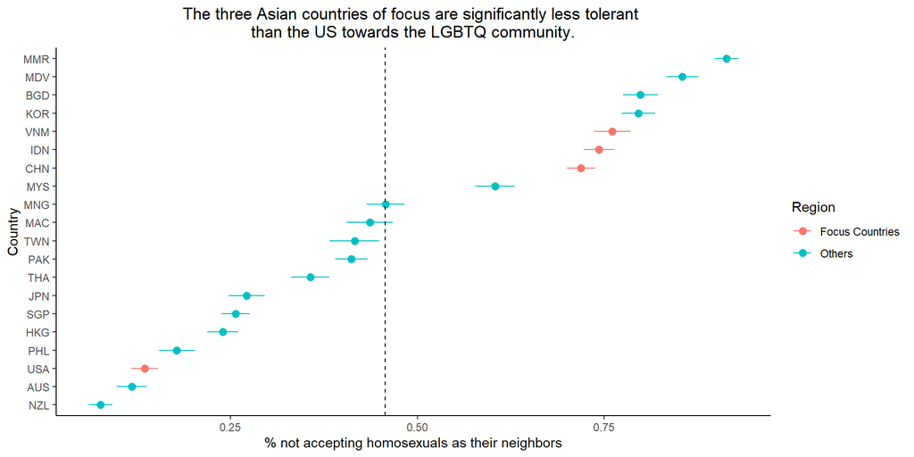

## Social Dimension

Chinese, Indonesians and Vietnamese respondents are more likely to *view family as being important*, *espouse intolerance towards marginalized groups* and *patriarchal views*, and *are happier!*

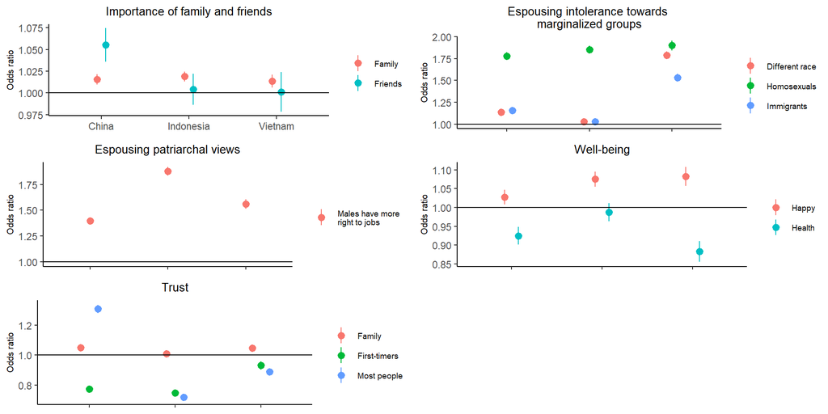

## Economic Dimension

Americans espouse privatization the most amongst all surveyed countries in Asia and North America.

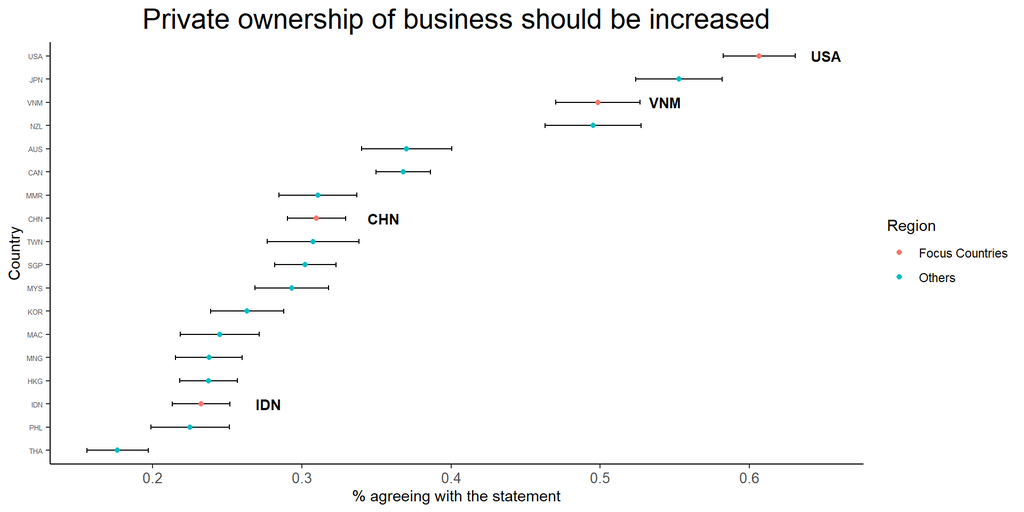

## Economic Dimension

Chinese, Indonesian and Vietnamese respondents have lesser odds of holding free market views as compared to Americans.

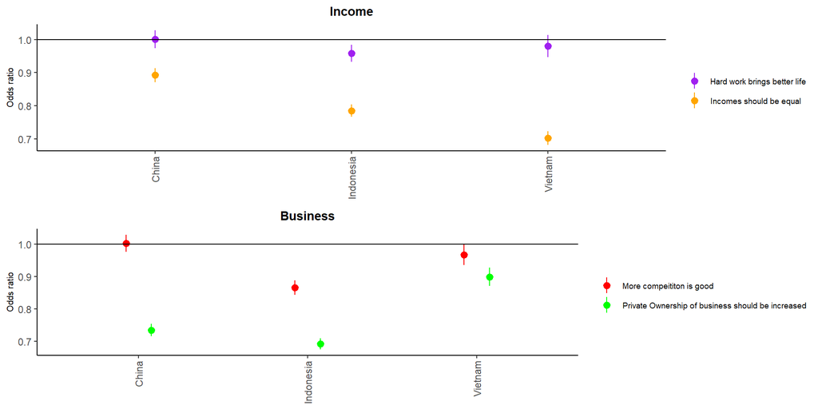

## Religious Dimension

Proportion of Indonesians and Chinese regarding their importance of God lie on extreme ends

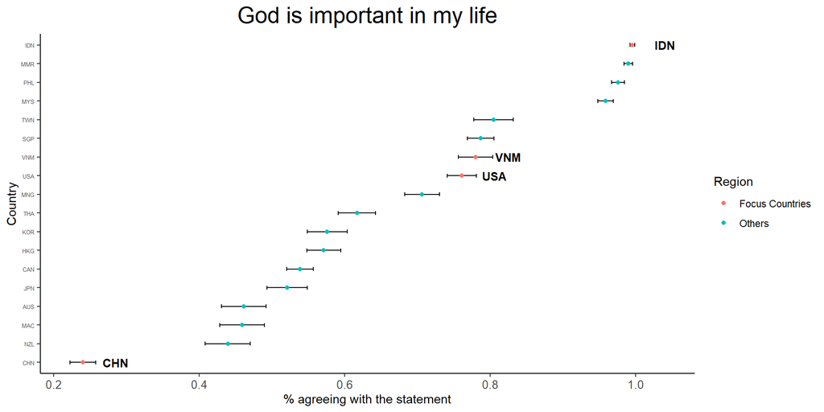

## Religious Dimension

Indonesia is most likely to hold strong religious beliefs as compared to China, Vietnam and the United States.

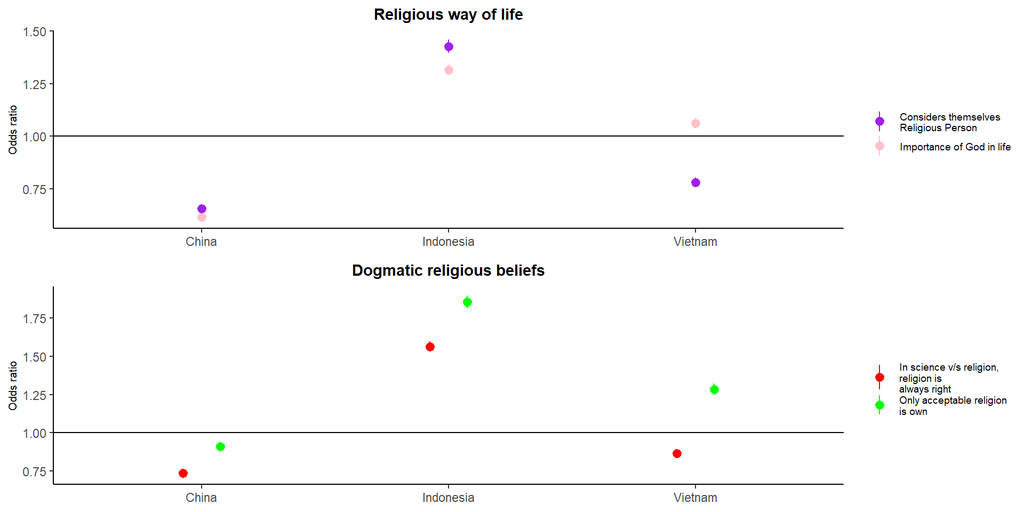

## Political Dimension

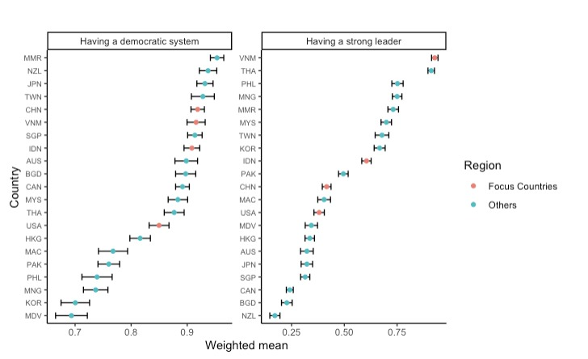

China, Vietnam and Indonesia agree more with having a strong democratic system and also a strong leader than USA.

## Political Dimension

Americans are *more willing* to *discuss political matters with friends* and *have more interest in politics* as compared to Asian countries. However, although Vietnamese are interested in politics, they aren’t willing to discuss these matters with friends.

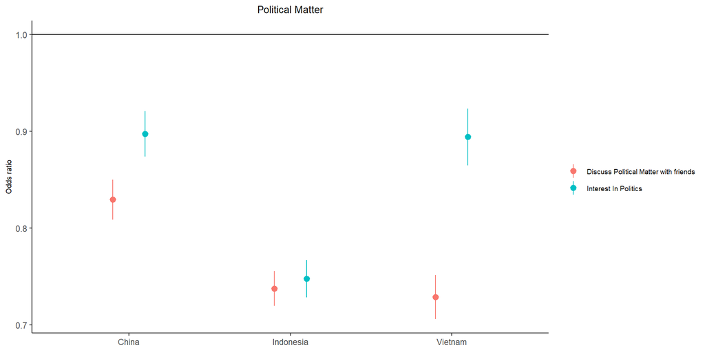

## Political Dimension

USA have strong political participation in terms of signing a petition, joining a boycott, attending peaceful demonstration and joining strikes.

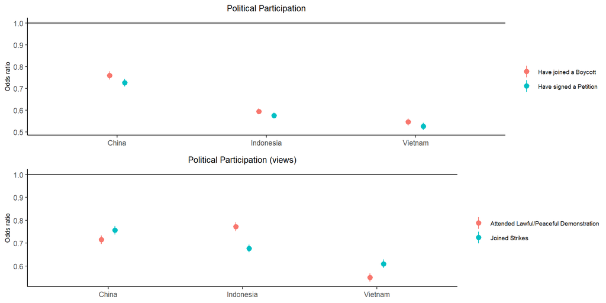

## Political Dimension

China, Indonesia and Vietnam wants to have a democratic political system more than USA, and Vietnam and Indonesia believe in having a strong leader who doesn’t bother with election.

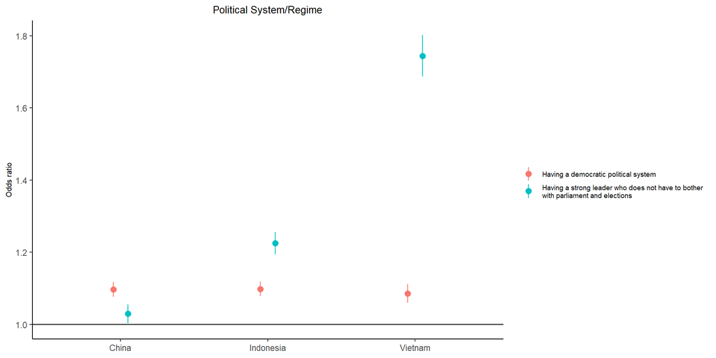

## Conclusion

**On our findings:**

- The results are consistent with our initial expectations and past literature, reinforcing the rebuttal that ‘the Asian value’ is not homogenous, nor is it monolithically different from that of the West (if arguing that there is a definitive one).
- The results also show some large overlap in ‘values’, confirming what (Wezel, 2011) would argue as a ‘universal model of human development’.
- The results are also largely consistent with our personal experience/on-the-ground perspective of our own countries.

## Conclusion

**On limitations and future improvements:**

- National-level aggregates can be unreliable to use as macro-level predictors with imprecise survey instruments
- Survey question wording can be more precise given its nuanced yet outsize implication (similarly with the 7-point agreement scale)
- Time-series analysis would be extremely useful to further investigate the universal human development model.
- More dimensions, more questions to be examined